# 資料分析實戰

Belle Liu

2017年2月23日

## Step 1. 讀取 Titanic 訓練資料

```r
  titanic <- read.csv("https://storage.googleapis.com/r_rookies/kaggle_titanic_train.csv")
```

#### 1.1. Titanic 資料框外觀

> Titanic資料共有12個變數，891筆觀測值

```
## 'data.frame':    891 obs. of  12 variables:
##  $ PassengerId: int  1 2 3 4 5 6 7 8 9 10 ...
##  $ Survived   : int  0 1 1 1 0 0 0 0 1 1 ...
##  $ Pclass     : int  3 1 3 1 3 3 1 3 3 2 ...
##  $ Name       : Factor w/ 891 levels "Abbing, Mr. Anthony",..: 109 191 358 277 16 559 520 629 417 581 ...
##  $ Sex        : Factor w/ 2 levels "female","male": 2 1 1 1 2 2 2 2 1 1 ...
##  $ Age        : num  22 38 26 35 35 NA 54 2 27 14 ...
##  $ SibSp      : int  1 1 0 1 0 0 0 3 0 1 ...
##  $ Parch      : int  0 0 0 0 0 0 0 1 2 0 ...
##  $ Ticket     : Factor w/ 681 levels "110152","110413",..: 524 597 670 50 473 276 86 396 345 133 ...
##  $ Fare       : num  7.25 71.28 7.92 53.1 8.05 ...
##  $ Cabin      : Factor w/ 148 levels "","A10","A14",..: 1 83 1 57 1 1 131 1 1 1 ...
##  $ Embarked   : Factor w/ 4 levels "","C","Q","S": 4 2 4 4 4 3 4 4 4 2 ...
```

#### 1.2. Titanic 描述性統計

> 在資料集裡，Age有177缺值、Embarked 有2個空值，這二個變數之遺漏值將會進一步處理，另外，Cabin雖然也有687筆空值，因為在這個案例裡，艙別被排除在影響因子之外，故其缺值估且忽略

```
##   PassengerId       Survived          Pclass
##  Min.   :  1.0   Min.   :0.0000   Min.   :1.000
##  1st Qu.:223.5   1st Qu.:0.0000   1st Qu.:2.000
##  Median :446.0   Median :0.0000   Median :3.000
##  Mean   :446.0   Mean   :0.3838   Mean   :2.309
##  3rd Qu.:668.5   3rd Qu.:1.0000   3rd Qu.:3.000
##  Max.   :891.0   Max.   :1.0000   Max.   :3.000
##
##                                     Name         Sex           Age
##  Abbing, Mr. Anthony                  :  1   female:314   Min.   : 0.42
##  Abbott, Mr. Rossmore Edward          :  1   male  :577   1st Qu.:20.12
##  Abbott, Mrs. Stanton (Rosa Hunt)     :  1                Median :28.00
##  Abelson, Mr. Samuel                  :  1                Mean   :29.70
##  Abelson, Mrs. Samuel (Hannah Wizosky):  1                3rd Qu.:38.00
##  Adahl, Mr. Mauritz Nils Martin       :  1                Max.   :80.00
##  (Other)                              :885                NA's   :177
##      SibSp           Parch             Ticket         Fare
##  Min.   :0.000   Min.   :0.0000   1601    :  7   Min.   :  0.00
##  1st Qu.:0.000   1st Qu.:0.0000   347082  :  7   1st Qu.:  7.91
##  Median :0.000   Median :0.0000   CA. 2343:  7   Median : 14.45
##  Mean   :0.523   Mean   :0.3816   3101295 :  6   Mean   : 32.20
##  3rd Qu.:1.000   3rd Qu.:0.0000   347088  :  6   3rd Qu.: 31.00
##  Max.   :8.000   Max.   :6.0000   CA 2144 :  6   Max.   :512.33
##                                   (Other) :852
##          Cabin     Embarked
##             :687    :  2
##  B96 B98    :  4   C:168
##  C23 C25 C27:  4   Q: 77
##  G6         :  4   S:644
##  C22 C26    :  3
##  D          :  3
##  (Other)    :186
```

#### 1.3. Titanic 缺失數據處理

> 利用 VIM 套件可以使用 aggr() 函式圖示化缺失值狀態

```r
  library("VIM")
  aggr(titanic, col=c("deepskyblue","firebrick1"), numbers=TRUE, sortVars=TRUE ,
       labels=names(titanic), cex.axis=.7, gap=3,
       ylab=c("Proportion of missingness","Missingness Pattern"))
```

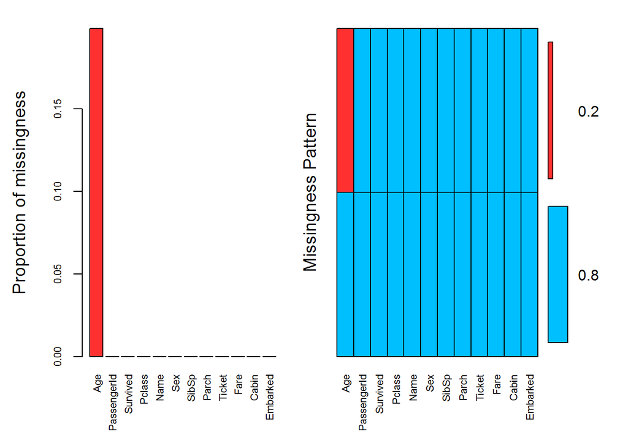

```
##
##  Variables sorted by number of missings:
##     Variable     Count
##          Age 0.1986532
##  PassengerId 0.0000000
##     Survived 0.0000000
##       Pclass 0.0000000
##         Name 0.0000000
##          Sex 0.0000000
##        SibSp 0.0000000
##        Parch 0.0000000
##       Ticket 0.0000000
##         Fare 0.0000000
##        Cabin 0.0000000
##     Embarked 0.0000000
```

#### 1.3.1. 利用 DMwR 套件的 k-Nearest Neighbours(KNN) 填補 Age 的缺值

> KNN 演算法是找一個和缺值最相似的資料，作為缺值的參考

```r
  library("DMwR")
  imputeData <- knnImputation(titanic)
  imputeData$Survived <- factor(imputeData$Survived)
```

#### 1.3.2. 以S填補Embarked的空值

```r
  imputeData$Embarked <- as.character(imputeData$Embarked)
  imputeData$Embarked[imputeData$Embarked == ""] <- "S"
  imputeData$Embarked <- factor(imputeData$Embarked)
```

## Step 2. 探索性分析

> 利用 ggplot2 與 plotly 套件先對資料進行觀察

```r
  library(ggplot2)
  library(plotly)
```

### 2.1. 盒鬚圖

> 觀察性別之間的存活與年齡的關係

```r
  gg1 <- ggplot(imputeData, aes(x=Survived,y=Age)) +
  geom_boxplot(aes( fill = Survived)) +
  ggtitle(label ="Survived V.S. Age By Sex") +
  xlab("Survived") +
  ylab("Age") +
  scale_fill_manual(values=c("deepskyblue", "firebrick1")) +
  facet_wrap(~ Sex)
  ggplotly(gg1)
```

[interactive chart not shown]

### 2.2. 長條圖

> 觀察各種等級的性別與存活的狀態比列

```r
    gg2 <- ggplot(imputeData, aes(x=Sex)) +
    geom_bar(aes(fill = Survived), position = "dodge") +
    ggtitle(label ="Survived V.S. Sex By Pclass") +
    xlab("Pclass") +
    ylab("Count") +
    scale_fill_manual(values=c("deepskyblue", "firebrick1")) +
    facet_wrap(~ Pclass)
    ggplotly(gg2)
```

[interactive chart not shown]

## Step 3. 建立模型分類

> 利用 rpart 與 randomForest 套件建立分類模型來預測 Survived 變數，再以正確率較高的較模型進行模型測試

```r
  library(rpart)
  library(randomForest)
```

#### 3.1. 使用 70/30 比例分割資料為訓練/測試樣本，訓練樣本共 624 筆，測試樣本共 267 筆

```r
  n <- nrow(imputeData)
  set.seed(87)
  shuffled_titanic <- imputeData[sample(n), ]
  train_indices <- 1:round(0.7 * n)
  train <- shuffled_titanic[train_indices, ]
  test_indices <- (round(0.7 * n) + 1):n
  test <- shuffled_titanic[test_indices, ]
```

#### 3.2. 利用 rpart() 函數建立決策樹分類模型來預測 Survived 變數

```r
  tree_fit <- rpart(Survived ~ Pclass + Sex + Age + SibSp+ Parch + Fare + Embarked ,
                    data = train, method = "class")
  prediction <- predict(tree_fit,
                        newdata=test[, c("Pclass", "Sex", "Age", "SibSp", "Parch", "Fare", "Embarked")],
                        type = "class")
  confusion_matrix <- table(test$Survived, prediction)
  confusion_matrix
```

```
##    prediction
##       0   1
##   0 155  14
##   1  28  70
```

```r
  accuracy <- sum(diag(confusion_matrix)) / sum(confusion_matrix)
  accuracy
```

```
## [1] 0.8426966
```

#### 3.3. 利用 randomForest() 函數建立隨機森林分類模型來預測 Survived 變數

```r
forest_fit <- randomForest(Survived ~ Pclass + Sex + Age + SibSp + Parch + Fare + Embarked,
                           data = train, ntree = 500)
prediction <- predict(forest_fit,
                      newdata = test[, c("Pclass", "Sex", "Age", "SibSp", "Parch", "Fare", "Embarked")])
confusion_matrix <- table(test$Survived, prediction)
confusion_matrix
```

```
##    prediction
##       0   1
##   0 152  17
##   1  22  76
```

```r
accuracy <- sum(diag(confusion_matrix)) / sum(confusion_matrix)
accuracy
```

```
## [1] 0.8539326
```

## Step 4. 探索沒有答案的上傳資料

```r
url <- "D:/R/hw_final/kaggle_titanic_test.csv"
to_predict <- read.csv(url)
summary(to_predict)
```

```
##   PassengerId         Pclass
##  Min.   : 892.0   Min.   :1.000
##  1st Qu.: 996.2   1st Qu.:1.000
##  Median :1100.5   Median :3.000
##  Mean   :1100.5   Mean   :2.266
##  3rd Qu.:1204.8   3rd Qu.:3.000
##  Max.   :1309.0   Max.   :3.000
##
##                                         Name         Sex
##  Abbott, Master. Eugene Joseph            :  1   female:152
##  Abelseth, Miss. Karen Marie              :  1   male  :266
##  Abelseth, Mr. Olaus Jorgensen            :  1
##  Abrahamsson, Mr. Abraham August Johannes :  1
##  Abrahim, Mrs. Joseph (Sophie Halaut Easu):  1
##  Aks, Master. Philip Frank                :  1
##  (Other)                                  :412
##       Age            SibSp            Parch             Ticket
##  Min.   : 0.17   Min.   :0.0000   Min.   :0.0000   PC 17608:  5
##  1st Qu.:21.00   1st Qu.:0.0000   1st Qu.:0.0000   113503  :  4
##  Median :27.00   Median :0.0000   Median :0.0000   CA. 2343:  4
##  Mean   :30.27   Mean   :0.4474   Mean   :0.3923   16966   :  3
##  3rd Qu.:39.00   3rd Qu.:1.0000   3rd Qu.:0.0000   220845  :  3
##  Max.   :76.00   Max.   :8.0000   Max.   :9.0000   347077  :  3
##  NA's   :86                                        (Other) :396
##       Fare                     Cabin     Embarked
##  Min.   :  0.000                  :327   C:102
##  1st Qu.:  7.896   B57 B59 B63 B66:  3   Q: 46
##  Median : 14.454   A34            :  2   S:270
##  Mean   : 35.627   B45            :  2
##  3rd Qu.: 31.500   C101           :  2
##  Max.   :512.329   C116           :  2
##  NA's   :1         (Other)        : 80
```

#### 4.1. 利用 VIM 套件 aggr() 函式圖示化缺失值狀態

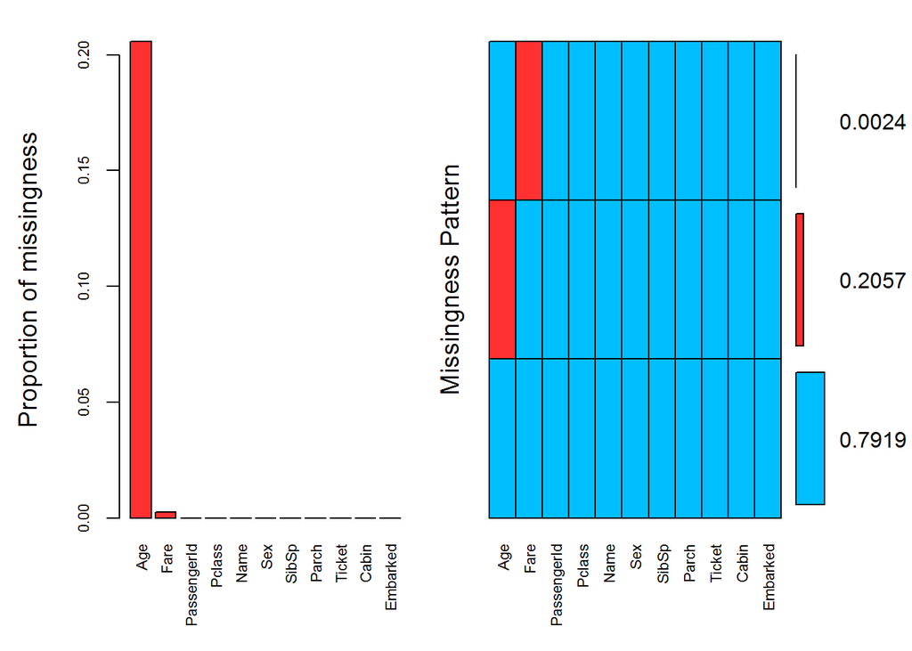

```
##
##  Variables sorted by number of missings:
##     Variable       Count
##          Age 0.205741627
##         Fare 0.002392344
##  PassengerId 0.000000000
##       Pclass 0.000000000
##         Name 0.000000000
##          Sex 0.000000000
##        SibSp 0.000000000
##        Parch 0.000000000
##       Ticket 0.000000000
##        Cabin 0.000000000
##     Embarked 0.000000000
```

```r
aggr(to_predict, col=c("deepskyblue","firebrick1"), numbers=TRUE, sortVars=TRUE ,
       labels=names(to_predict), cex.axis=.7, gap=3,
       ylab=c("Proportion of missingness","Missingness Pattern"))
```

#### 4.2. 填補遺漏值

> 利用 DMwR 套件的 k-Nearest Neighbours(KNN) 填補 Age與Fare 的缺值

```r
  predictData <- knnImputation(to_predict)
  summary(predictData)
```

```
##   PassengerId         Pclass
##  Min.   : 892.0   Min.   :1.000
##  1st Qu.: 996.2   1st Qu.:1.000
##  Median :1100.5   Median :3.000
##  Mean   :1100.5   Mean   :2.266
##  3rd Qu.:1204.8   3rd Qu.:3.000
##  Max.   :1309.0   Max.   :3.000
##
##                                         Name         Sex
##  Abbott, Master. Eugene Joseph            :  1   female:152
##  Abelseth, Miss. Karen Marie              :  1   male  :266
##  Abelseth, Mr. Olaus Jorgensen            :  1
##  Abrahamsson, Mr. Abraham August Johannes :  1
##  Abrahim, Mrs. Joseph (Sophie Halaut Easu):  1
##  Aks, Master. Philip Frank                :  1
##  (Other)                                  :412
##       Age            SibSp            Parch             Ticket
##  Min.   : 0.17   Min.   :0.0000   Min.   :0.0000   PC 17608:  5
##  1st Qu.:22.00   1st Qu.:0.0000   1st Qu.:0.0000   113503  :  4
##  Median :27.00   Median :0.0000   Median :0.0000   CA. 2343:  4
##  Mean   :29.45   Mean   :0.4474   Mean   :0.3923   16966   :  3
##  3rd Qu.:36.00   3rd Qu.:1.0000   3rd Qu.:0.0000   220845  :  3
##  Max.   :76.00   Max.   :8.0000   Max.   :9.0000   347077  :  3
##                                                    (Other) :396
##       Fare                     Cabin     Embarked
##  Min.   :  0.000                  :327   C:102
##  1st Qu.:  7.896   B57 B59 B63 B66:  3   Q: 46
##  Median : 14.454   A34            :  2   S:270
##  Mean   : 35.765   B45            :  2
##  3rd Qu.: 31.500   C101           :  2
##  Max.   :512.329   C116           :  2
##                    (Other)        : 80
```

#### 4.3. 以隨機森林分類模型來進行測試

> 由於建模時隨機森林的模型正確率略高於決策樹，所以決定以隨機森林模型進行實測

```r
  predicted <- predict(forest_fit,
                     newdata = predictData[, c("Pclass", "Sex", "Age", "SibSp",
                                               "Parch", "Fare", "Embarked")])
  to_submit <- data.frame(predictData[, "PassengerId"], predicted)
  names(to_submit) <- c("PassengerId", "Survived")
  head(to_submit, n = 10)
```

```
##    PassengerId Survived
## 1          892        0
## 2          893        0
## 3          894        0
## 4          895        0
## 5          896        0
## 6          897        0
## 7          898        1
## 8          899        0
## 9          900        1
## 10         901        0
```

#### 4.4. 準備上傳檔案

> 上傳結果正確率僅僅 75%

```r
  write.csv(to_submit, file = "to_submit.csv", row.names = FALSE)
```

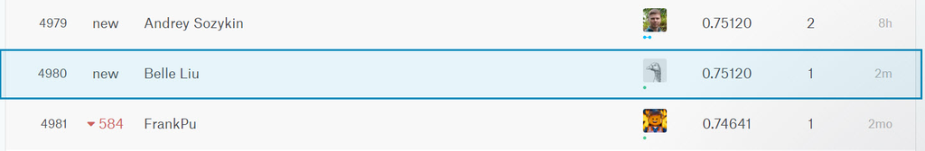